# Scenario Analyses with the random walk IBM

# Objectives

The aim of this tutorial is to run scenairo analyses with the random walk individual-based model in R from the previous tutorial.

In this session, you will

1. Run the IBM with different model parameters
2. Discuss the impact of transmission parameters and features

The best thing to do is to read each section and type (or copy and paste) the R commands (in grey boxes) into your own R session to check that you understand the code.

# Set working directory

The first step when creating a new R file is to specify a working directory. You need to tell the R session where you want it to work. To do this you use the command to “set the working directory” or `setwd()`.

You can label this working directory as ‘home’, and have other locations stored for plotting or for getting data. For example

```r
home <- "~/Documents/Modelling_intro/" ## on a OS X
home <- "C:\\Documents\\Modelling_intro\\" ## on windows
setwd(home)
```

# Load model code

You can use your model from the previous tutorial, or load an IBM function from the GitHub repository.

```r
# download R file with IBM function
curl_download("https://github.com/lwillem/modelling-intro/raw/master/lib/ibm_functions.R", destfile = "ibm_functions.R")
source('ibm_functions.R')
```

# Scenario analyses

Now you have a working model, you can start changing input parameters and explore the effect on the transmission dynamics. First, lets run our model with the default parameters:

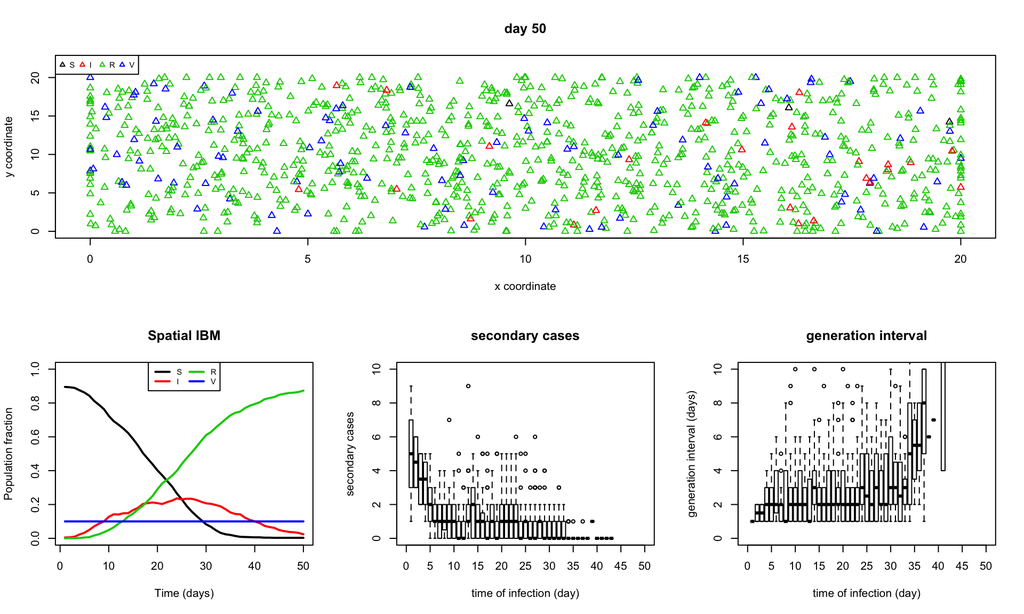

```
## [1] "MODEL PARAMETERS"
## [1] "pop_size : 1000"
## [1] "num_days : 50"
## [1] "num_infected_seeds : 3"
## [1] "vaccine_coverage : 0.1"
## [1] "apply_spatial_vaccine_refusal : FALSE"
## [1] "rng_seed : 13"
## [1] "area_size : 20"
## [1] "max_velocity : 1"
## [1] "num_contacts_day : 10"
## [1] "max_contact_distance : 2"
## [1] "num_days_infected : 7"
## [1] "transmission_prob : 0.1"
## [1] "plot_time_delay : 0"
## [1] "-------------"
## [1] "MODEL RESULTS"
## [1] "total incidence: 89.7%"
## [1] "Peak prevalence: 23.6%"
## [1] "Peak day:        24"
```

```r
# you can run the IBM with default parameters (see console)
run_ibm_random_walk()
```

What can you learn from these graphs?

## Dynamics over time?

This IBM is able to show the location and health states of each individual over time. Therefore, you have to increase the parameter `plot_time_delay` to set a delay between two time steps (= default this is 0 = no time between 2 time steps = no plots)

```r
# you can run the IBM with default parameters (see console)
run_ibm_random_walk(plot_time_delay = 0.2)
```

## Vaccination?

This IBM is able to account for vaccination. Therefore, you have to increase the parameter `vaccine_coverage`. By default, the vacciated individuals are randomly distributed over the area.

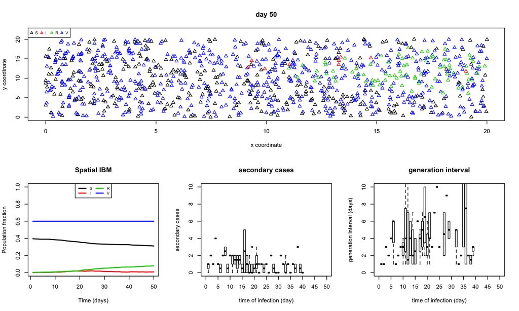

```
## [1] "MODEL PARAMETERS"
## [1] "pop_size : 1000"
## [1] "num_days : 50"
## [1] "num_infected_seeds : 3"
## [1] "vaccine_coverage : 0.6"
## [1] "apply_spatial_vaccine_refusal : FALSE"
## [1] "rng_seed : 17"
## [1] "area_size : 20"
## [1] "max_velocity : 0"
## [1] "num_contacts_day : 10"
## [1] "max_contact_distance : 2"
## [1] "num_days_infected : 7"
## [1] "transmission_prob : 0.1"
## [1] "plot_time_delay : 0"
## [1] "-------------"
## [1] "MODEL RESULTS"
## [1] "total incidence: 8.9%"
## [1] "Peak prevalence: 2.2%"
## [1] "Peak day:        25"
```

```r
# set vaccination coverage to 60% with population that does not move
run_ibm_random_walk(max_velocity = 0,
                    vaccine_coverage = 0.6)
```

## Clustered vaccine refusal?

What happens if vaccine refusal is geographically clustered, and individuals do not move? Run the following and have a look at the outcomes.

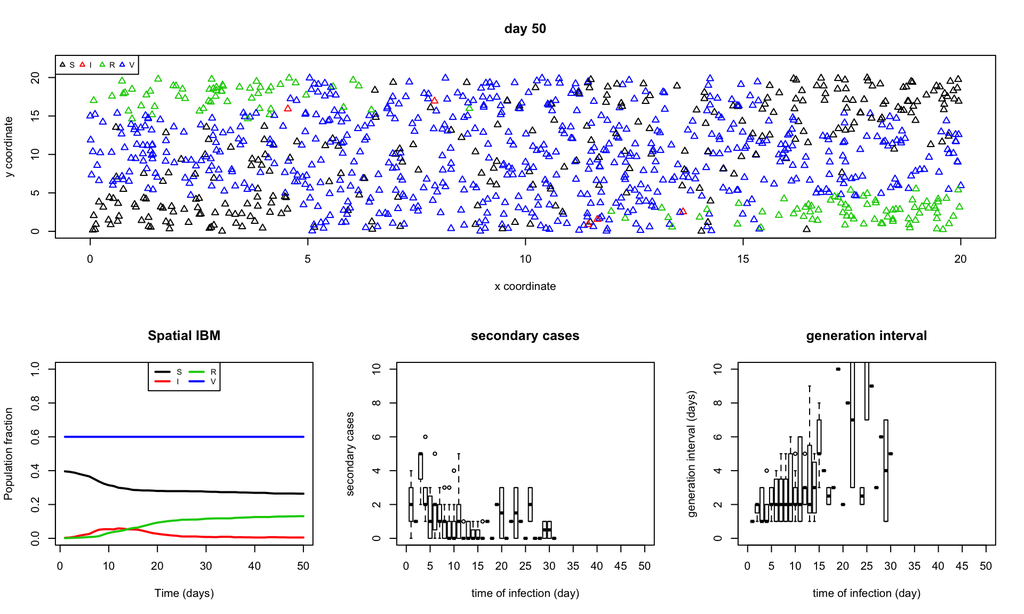

```
## [1] "MODEL PARAMETERS"
## [1] "pop_size : 1000"
## [1] "num_days : 50"
## [1] "num_infected_seeds : 3"
## [1] "vaccine_coverage : 0.6"
## [1] "apply_spatial_vaccine_refusal : TRUE"
## [1] "rng_seed : 20"
## [1] "area_size : 20"
## [1] "max_velocity : 0"
## [1] "num_contacts_day : 10"
## [1] "max_contact_distance : 2"
## [1] "num_days_infected : 7"
## [1] "transmission_prob : 0.1"
## [1] "plot_time_delay : 0"
## [1] "-------------"
## [1] "MODEL RESULTS"
## [1] "total incidence: 13.6%"
## [1] "Peak prevalence: 5.9%"
## [1] "Peak day:        12"
```

```r
# is vaccination clustered?
run_ibm_random_walk(max_velocity = 0,
                    vaccine_coverage = 0.6,
                    apply_spatial_vaccine_refusal = TRUE)
```

## Scenarios…

Now, what happens if you…

- increase the population size?
- decrease the area size?
- change the velocity?
- start with more infected indviduals?
- increase the contact range?
- increase the transmission probability?
- decrease the average number of contacts per day?
- change the time horizon?
- … etc.

# Navigate

Top: Index Next: IBM household transmission